# Moral conventional: Study 1

Rose M. Schneider

3/3/2021

# Study 1

## Participants

### Overall age demographics

```r
study1_data %>%
  distinct(subid, site, age)%>%
  group_by(site)%>%
  summarise_at('age',
               list(~mean(., na.rm=T),
                    ~sd(., na.rm=T),
                    ~median(., na.rm=T),
                    ~min(., na.rm=T),
                    ~max(., na.rm=T),
                    ~sum(!is.na(.))))%>%
  dplyr::rename("n" = "sum")%>%
  dplyr::select(site, n, mean, sd, median, min, max)%>%
  mutate(total.n = sum(n))%>%
  knitr::kable()
```

| site | n | mean | sd | median | min | max | total.n |
| --- | --- | --- | --- | --- | --- | --- | --- |
| Canada | 80 | 7.812817 | 1.590593 | 7.927447 | 5.084189 | 10.80082 | 268 |
| India | 73 | 9.516169 | 1.319499 | 10.198494 | 7.159480 | 10.99247 | 268 |
| Iran | 84 | 7.657024 | 1.612185 | 7.945000 | 4.970000 | 10.35000 | 268 |
| Korea | 31 | 8.980645 | 1.030993 | 8.400000 | 7.800000 | 10.60000 | 268 |

```r
##total mean age, sd
mean(study1_data$age)
```

```
## [1] 8.363044
```

```r
sd(study1_data$age)
```

```
## [1] 1.67056
```

### Age bin and sex counts

```r
study1_data %>%
  distinct(subid, site, age.bin, sex)%>%
  group_by(site, age.bin, sex)%>%
  summarise(n = n())%>%
  group_by(site)%>%
  mutate(total.site.n = sum(n))%>%
  knitr::kable()
```

| site | age.bin | sex | n | total.site.n |
| --- | --- | --- | --- | --- |
| Canada | 5-6 | F | 13 | 80 |
| Canada | 5-6 | M | 17 | 80 |
| Canada | 7-8 | F | 11 | 80 |
| Canada | 7-8 | M | 17 | 80 |
| Canada | 9-10 | F | 14 | 80 |
| Canada | 9-10 | M | 8 | 80 |
| India | 7-8 | F | 7 | 73 |
| India | 7-8 | M | 21 | 73 |
| India | 9-10 | F | 14 | 73 |
| India | 9-10 | M | 19 | 73 |
| India | 9-10 | NA | 12 | 73 |
| Iran | 5-6 | F | 15 | 84 |
| Iran | 5-6 | M | 16 | 84 |
| Iran | 7-8 | F | 12 | 84 |
| Iran | 7-8 | M | 18 | 84 |
| Iran | 9-10 | F | 15 | 84 |
| Iran | 9-10 | M | 8 | 84 |
| Korea | 7-8 | F | 9 | 31 |
| Korea | 7-8 | M | 9 | 31 |
| Korea | 9-10 | F | 3 | 31 |
| Korea | 9-10 | M | 10 | 31 |

```r
study1_data %>%
  distinct(subid, site, sex)%>%
  group_by(site, sex)%>%
  summarise(n = n())%>%
  group_by(site)%>%
  mutate(total.site.n = sum(n))%>%
  knitr::kable()
```

| site | sex | n | total.site.n |
| --- | --- | --- | --- |
| Canada | F | 38 | 80 |
| Canada | M | 42 | 80 |
| India | F | 21 | 73 |
| India | M | 40 | 73 |
| India | NA | 12 | 73 |
| Iran | F | 42 | 84 |
| Iran | M | 42 | 84 |
| Korea | F | 12 | 31 |
| Korea | M | 19 | 31 |

## Ratings for moral and conventional items by testing site

### Descriptives

```r
study1_data %>%
  filter(q_kind == 0)%>%
  group_by(site, task)%>%
  summarise_at('answer',
               list(~mean(., na.rm=T),
                    ~sd(., na.rm=T),
                    ~median(., na.rm=T),
                    ~min(., na.rm=T),
                    ~max(., na.rm=T),
                    ~sum(!is.na(.))))%>%
  dplyr::rename("n" = "sum")%>%
  dplyr::select(site, task, n, mean, sd, median, min, max)%>%
  knitr::kable()
```

| site | task | n | mean | sd | median | min | max |
| --- | --- | --- | --- | --- | --- | --- | --- |
| Canada | conv | 318 | 2.261006 | 0.9619520 | 2 | 1 | 6 |
| Canada | moral | 239 | 1.761506 | 0.8730461 | 2 | 1 | 6 |
| India | conv | 289 | 1.674740 | 1.3862239 | 1 | 1 | 6 |
| India | moral | 217 | 1.184332 | 0.5956118 | 1 | 1 | 6 |
| Iran | conv | 330 | 1.333333 | 0.7216440 | 1 | 1 | 5 |
| Iran | moral | 258 | 1.248062 | 0.5987147 | 1 | 1 | 6 |
| Korea | conv | 124 | 1.693548 | 0.7878903 | 2 | 1 | 5 |
| Korea | moral | 93 | 1.354839 | 0.5831914 | 1 | 1 | 3 |

```r
study1_data %>%
  filter(q_kind == 0)%>%
  group_by(site, item)%>%
  summarise_at('answer',
               list(~mean(., na.rm=T),
                    ~sd(., na.rm=T),
                    ~median(., na.rm=T),
                    ~min(., na.rm=T),
                    ~max(., na.rm=T),
                    ~sum(!is.na(.))))%>%
  dplyr::rename("n" = "sum")%>%
  dplyr::select(site, item, n, mean, sd, median, min, max)%>%
  knitr::kable()
```

| site | item | n | mean | sd | median | min | max |
| --- | --- | --- | --- | --- | --- | --- | --- |
| Canada | namecall | 80 | 1.850000 | 0.9426599 | 2 | 1 | 6 |
| Canada | push | 80 | 1.800000 | 0.8018965 | 2 | 1 | 3 |
| Canada | rip | 79 | 1.632911 | 0.8649472 | 1 | 1 | 6 |
| Canada | shoes | 79 | 2.329114 | 0.9570457 | 2 | 1 | 6 |
| Canada | swim | 80 | 2.500000 | 1.0311601 | 3 | 1 | 5 |
| Canada | teachername | 79 | 1.962025 | 0.9666627 | 2 | 1 | 6 |
| Canada | toy | 80 | 2.250000 | 0.8190764 | 2 | 1 | 3 |
| India | namecall | 72 | 1.222222 | 0.6965149 | 1 | 1 | 6 |
| India | push | 72 | 1.138889 | 0.5387925 | 1 | 1 | 5 |
| India | rip | 73 | 1.191781 | 0.5440980 | 1 | 1 | 4 |
| India | shoes | 73 | 1.397260 | 1.1022669 | 1 | 1 | 6 |
| India | swim | 73 | 1.863014 | 1.5839040 | 1 | 1 | 6 |
| India | teachername | 72 | 1.555556 | 1.4031041 | 1 | 1 | 6 |
| India | toy | 71 | 1.887324 | 1.3789157 | 1 | 1 | 6 |
| Iran | namecall | 86 | 1.360465 | 0.6492129 | 1 | 1 | 3 |
| Iran | push | 86 | 1.186047 | 0.6419021 | 1 | 1 | 6 |
| Iran | rip | 86 | 1.197674 | 0.4806801 | 1 | 1 | 3 |
| Iran | shoes | 82 | 1.207317 | 0.5824131 | 1 | 1 | 4 |
| Iran | swim | 82 | 1.378049 | 0.7640090 | 1 | 1 | 5 |
| Iran | teachername | 82 | 1.243902 | 0.6769754 | 1 | 1 | 5 |
| Iran | toy | 84 | 1.500000 | 0.8140335 | 1 | 1 | 5 |
| Korea | namecall | 31 | 1.483871 | 0.6768046 | 1 | 1 | 3 |
| Korea | push | 31 | 1.354839 | 0.5506594 | 1 | 1 | 3 |
| Korea | rip | 31 | 1.225807 | 0.4973046 | 1 | 1 | 3 |
| Korea | shoes | 31 | 1.870968 | 0.7184212 | 2 | 1 | 3 |
| Korea | swim | 31 | 1.870968 | 0.8058923 | 2 | 1 | 3 |
| Korea | teachername | 31 | 1.064516 | 0.2497310 | 1 | 1 | 2 |
| Korea | toy | 31 | 1.967742 | 0.8749808 | 2 | 1 | 5 |

### Visualization of mean rating (all items collapsed) by site

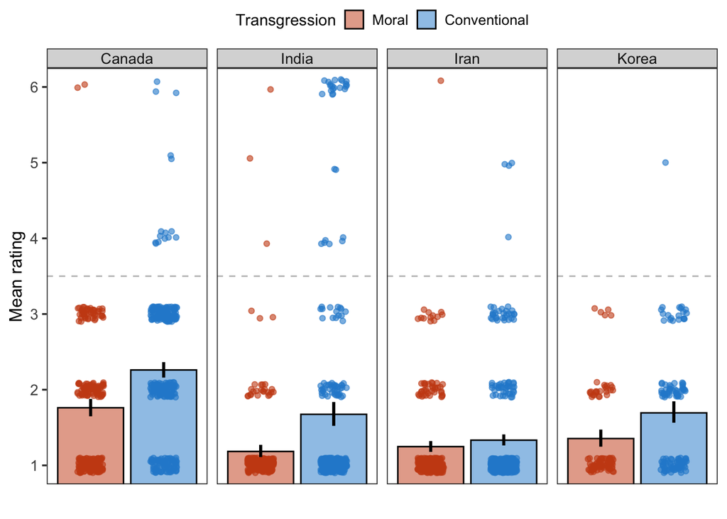

```r
study1_data %>%
  filter(q_kind == 0)%>%
  mutate(task = factor(task, levels = c("moral", "conv"),
                       labels = c("Moral", "Conventional")))%>%
  ggplot(aes(x = task, y = answer, fill = task, color = task)) +
  stat_summary(fun = mean, position = position_dodge(width = .9),
               geom="bar", alpha = .5, colour = "black") +
  geom_point(position=position_jitter(width = .18, height = .1),
             size=1.5,
             alpha = .6,
             show.legend=FALSE,
             inherit.aes = TRUE) +
  geom_hline(yintercept = 3.5, color = "grey", linetype = "dashed") +
  facet_grid(~site) +
  coord_cartesian(ylim = c(1, 6)) +
  stat_summary(fun.data = "mean_cl_boot", geom="linerange",
               position = position_dodge(width=0.9), size = 1, color = "black") +
  theme(legend.position = "top",
        axis.text.x = element_blank(),
        axis.ticks.x = element_blank(),
        legend.key.size = unit(.5, 'cm'),
        legend.text = element_text(size = 10),
        legend.title = element_text(size = 11),
        legend.margin=margin(t = 0, unit='cm')) +
  langcog::scale_color_solarized() +
  langcog::scale_fill_solarized() +
  labs(y = "Mean rating",
       x = "",
       fill = "Transgression") +
  scale_y_continuous(breaks = seq(1,6, 1))
```

```r
ggsave("mean_ratings_study1.png", height = 3)
```

### Visualization of ratings by age by site

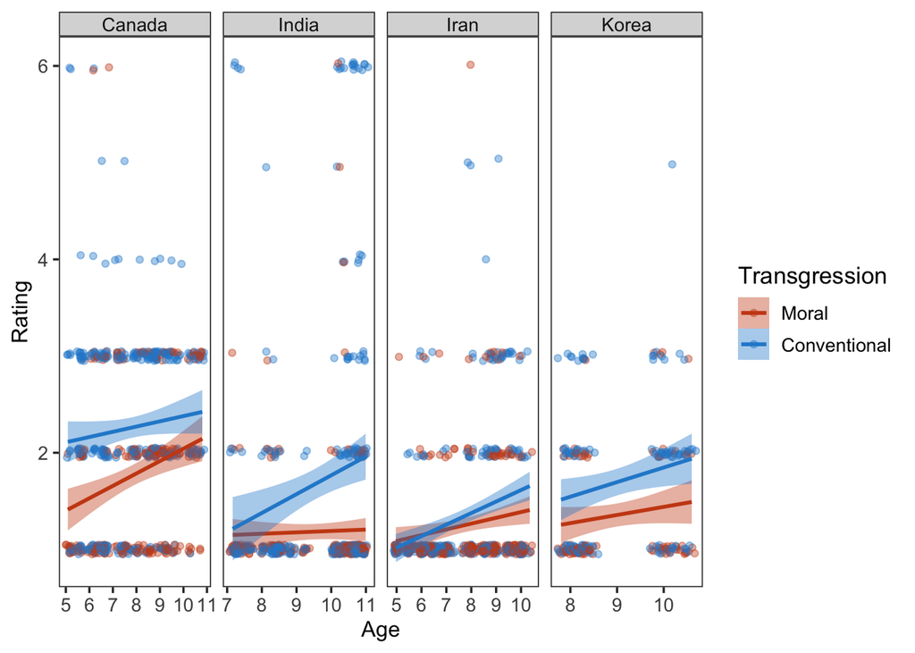

```r
study1_data %>%
  filter(q_kind == 0)%>%
  dplyr::rename("Transgression" = "task")%>%
  mutate(Transgression = factor(Transgression, levels = c("moral", "conv"),
                                labels = c("Moral", "Conventional")))%>%
  ggplot(aes(x = age, y= answer, color = Transgression, fill = Transgression)) +
  geom_point(position = position_jitter(width = .1, height = .05),
             alpha = .4) +
  geom_smooth(method ="lm") +
  langcog::scale_color_solarized() +
  langcog::scale_fill_solarized() +
  labs(x = "Age",
       y = "Rating") +
  facet_grid(~site, scale = "free_x")
```

### Visualization of mean rating (by item) by site

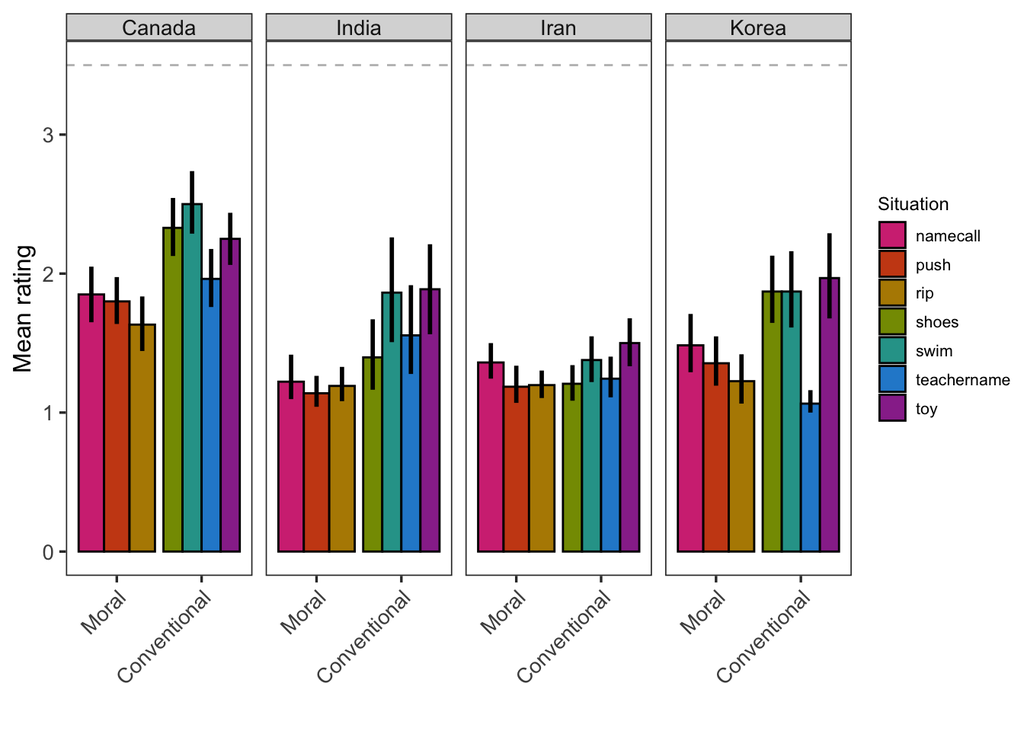

```r
study1_data %>%
  filter(q_kind == 0)%>%
  mutate(task = factor(task, levels = c("moral", "conv"),
                       labels = c("Moral", "Conventional")))%>%
  ggplot(aes(x = task, y = answer, fill = item)) +
  stat_summary(fun = mean, position = position_dodge(width = .9),
               geom="bar", colour = "black") +
  stat_summary(fun.data = "mean_cl_boot", geom="linerange",
               position = position_dodge(width=0.9), size = 1, color = "black") +
  geom_hline(yintercept = 3.5, color = "grey", linetype = "dashed") +
  facet_grid(~site) +
  theme(legend.position = "right",
        legend.key.size = unit(.5, 'cm'),
        legend.text = element_text(size = 8),
        legend.title = element_text(size = 9),
        legend.margin=margin(t = 0, unit='cm'),
        axis.text.x = element_text(hjust = 1, angle = 45)) +
  langcog::scale_color_solarized() +
  langcog::scale_fill_solarized() +
  labs(y = "Mean rating",
       x = "",
       fill = "Situation")
```

### Analyses of differences in rating between moral and conventional transgressions: Within-country

Pre-registered mixed-effects model: Rating ~ Transgression type (moral; conventional)*Age + (Transgression type|Subject) + (age|item).

We will iteratively remove item slopes, then subject slopes, then will remove item effects altogether if necessary.

#### High-level summary of these models:

1. *The one exception* is Korea, where we *do not* find a significant difference when we include a random intercept of item to the model. This is because, while in general Korean children give higher ratings to conventional items, they give an extremely low rating to the “teachername” item. If you run the model without the item random intercept, there is a significant difference between moral and conventional items.
2. For India: In general, there is a significant interaction between age and task, and this holds true with or without item random intercept. If we remove the item random intercept, there is a significant difference between moral and conventional items.

#### India

##### Model: Answer ~ Task + Age + Task:Age + (1|subid) + (1|item)

1. Interaction between task and age significantly improves the fit of the model ($\chi^{2}$ = 7.68, *p* = .006)
2. No significant difference between moral and conventional items ($\beta$ = 0.28, *p* = .11)
3. No significant effect of age ($\beta$ = 0.02, *p* = .85)
4. Significant interaction between transgression type and age: as children age, they are more likely to give higher ratings for conventional transgressions in comparison to moral transgressions ($\beta$ = .30, *p* = .006)

```r
#summary of item model
knitr::kable(summary(ratings.india)$coef)
```

|  | Estimate | Std. Error | df | t value | Pr(>\|t\|) |
| --- | --- | --- | --- | --- | --- |
| (Intercept) | 1.1695669 | 0.1503933 | 18.487776 | 7.7767207 | 0.0000003 |
| taskconv | 0.2825694 | 0.1598221 | 8.210336 | 1.7680248 | 0.1140694 |
| age.c | 0.0222982 | 0.1179853 | 129.880379 | 0.1889914 | 0.8503946 |
| taskconv:age.c | 0.2983360 | 0.1074563 | 426.931432 | 2.7763464 | 0.0057392 |

#### Iran

##### Model: Answer ~ Task + Age + (task|subid) + (1|item)

1. Interaction between task and age does not significantly improve model fit ($\chi^{2}$ = 3.10, *p* = .08)
2. No significant difference between moral and conventional items ($\beta$ = 0.09, *p* = .41)
3. Significant effect of age, with increases in ratings as children age ($\beta$ = 0.14, *p* = .002)

```r
## here are main effects from full model
knitr::kable(summary(ratings.iran.base)$coef)
```

|  | Estimate | Std. Error | df | t value | Pr(>\|t\|) |
| --- | --- | --- | --- | --- | --- |
| (Intercept) | 1.3060143 | 0.0768119 | 7.473925 | 17.0027621 | 0.0000003 |
| taskconv | 0.0857736 | 0.0969748 | 6.241668 | 0.8844941 | 0.4092055 |
| age.c | 0.1359643 | 0.0418162 | 81.957237 | 3.2514753 | 0.0016674 |

#### Canada

##### Model: Answer ~ Task + Age + (1|subid) + (1|item)

1. Interaction between task and age does not significantly improve the fit of the model ($\chi^{2}$ = 2.87, *p* = .09)
2. Significant difference between moral and conventional items ($\beta$ = 0.50, *p* = .02)
3. Significant effect of age ($\beta$ = 0.14, *p* = .02)

```r
## Summary of main effects
knitr::kable(summary(ratings.canada.base)$coef)
```

|  | Estimate | Std. Error | df | t value | Pr(>\|t\|) |
| --- | --- | --- | --- | --- | --- |
| (Intercept) | 1.8080246 | 0.1204113 | 7.238769 | 15.015402 | 0.0000010 |
| taskconv | 0.4976876 | 0.1449254 | 4.993027 | 3.434095 | 0.0185945 |
| age.c | 0.1430022 | 0.0604577 | 77.907927 | 2.365326 | 0.0205019 |

#### Korea

**NB** with Korea dataset: When we include the item random effect, we find that there is **no** difference between moral and conventional items. This means that the variance in the intercepts associated with these items that there is reason to call into question whether there is an overall difference between these moral and conventional items. I confirmed that this is driven by the abnormally low ratings for the “teachername” item. If you remove this item and run the model, you find that the difference between moral and conventional is significant.

##### Model: Answer ~ Task + Age + (1|subid) + (1|item)

1. The task x age interaction does not significantly improve the fit of the model ($\chi^{2}$ = 0.71, *p* = .40)
2. No significant difference between moral and conventional items ($\beta$ = 0.34, *p* = .25)
3. Marginal effect of age, with increases in ratings as children age ($\beta$ = 0.20, *p* = .06)

Summary of main effects with item random effect

```r
#summary of main effects
knitr::kable(summary(ratings.korea.base)$coef)
```

|  | Estimate | Std. Error | df | t value | Pr(>\|t\|) |
| --- | --- | --- | --- | --- | --- |
| (Intercept) | 1.2792961 | 0.2037838 | 6.011542 | 6.277712 | 0.0007541 |
| taskconv | 0.3387097 | 0.2572231 | 4.999999 | 1.316793 | 0.2450298 |
| age.c | 0.2043363 | 0.1025683 | 28.999996 | 1.992196 | 0.0558387 |

Summary of main effects without item-level random effect

```r
knitr::kable(summary(ratings.korea.noitem)$coef)
```

|  | Estimate | Std. Error | df | t value | Pr(>\|t\|) |
| --- | --- | --- | --- | --- | --- |
| (Intercept) | 1.2792961 | 0.0892714 | 62.73402 | 14.330415 | 0.0000000 |
| taskconv | 0.3387097 | 0.0901517 | 185.00000 | 3.757109 | 0.0002302 |
| age.c | 0.2043363 | 0.1025683 | 29.00000 | 1.992196 | 0.0558387 |

=====

## Judgments of transgression acceptability under certain circumstances

### Descriptives

```r
study1_data %>%
  filter(q_kind != 0)%>%
  group_by(site, task, q_kind_label)%>%
  summarise_at('answer',
               list(~mean(., na.rm=T),
                    ~sd(., na.rm=T),
                    ~sum(!is.na(.))))%>%
  dplyr::rename("n" = "sum")%>%
  dplyr::select(site, task, q_kind_label, n, mean, sd)%>%
  knitr::kable()
```

| site | task | q_kind_label | n | mean | sd |
| --- | --- | --- | --- | --- | --- |
| Canada | conv | Everyone else | 320 | 0.1937500 | 0.3958543 |
| Canada | conv | Faraway country | 321 | 0.2242991 | 0.4177711 |
| Canada | conv | Rule at school | 320 | 0.4812500 | 0.5004308 |
| Canada | moral | Everyone else | 240 | 0.0958333 | 0.2949777 |
| Canada | moral | Faraway country | 240 | 0.0958333 | 0.2949777 |
| Canada | moral | Rule at school | 240 | 0.3375000 | 0.4738452 |
| India | conv | Everyone else | 291 | 0.3402062 | 0.4745945 |
| India | conv | Faraway country | 291 | 0.0756014 | 0.2648146 |
| India | conv | Rule at school | 291 | 0.2542955 | 0.4362146 |
| India | moral | Everyone else | 214 | 0.2476636 | 0.4326674 |
| India | moral | Faraway country | 216 | 0.0925926 | 0.2905340 |
| India | moral | Rule at school | 217 | 0.2165899 | 0.4128732 |
| Iran | conv | Everyone else | 331 | 0.0664653 | 0.2494707 |
| Iran | conv | Faraway country | 330 | 0.0909091 | 0.2879164 |
| Iran | conv | Rule at school | 329 | 0.1489362 | 0.3565679 |
| Iran | moral | Everyone else | 258 | 0.0387597 | 0.1933969 |
| Iran | moral | Faraway country | 258 | 0.0426357 | 0.2024270 |
| Iran | moral | Rule at school | 258 | 0.1395349 | 0.3471773 |
| Korea | conv | Everyone else | 123 | 0.3333333 | 0.4733326 |
| Korea | conv | Faraway country | 123 | 0.0325203 | 0.1781029 |
| Korea | conv | Rule at school | 117 | 0.1538462 | 0.3623531 |
| Korea | moral | Everyone else | 93 | 0.1397849 | 0.3486433 |
| Korea | moral | Faraway country | 93 | 0.0107527 | 0.1036952 |
| Korea | moral | Rule at school | 89 | 0.0674157 | 0.2521612 |

### Visualization of acceptability (all items collapsed) by site

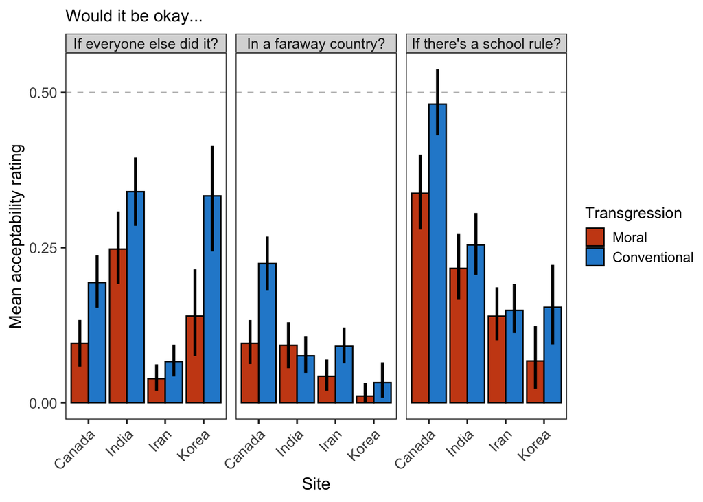

```r
study1_data %>%
  filter(q_kind != 0)%>%
  mutate(task = factor(task, levels = c("moral", "conv"),
                       labels = c("Moral", "Conventional")),
         q_kind_label = factor(q_kind_label, labels = c("If everyone else did it?",
                                                        "In a faraway country?",
                                                        "If there's a school rule?")))%>%
  ggplot(aes(x = site, y = answer, fill = task, color = task)) +
  stat_summary(fun = mean, position = position_dodge(width = .9),
               geom="bar", colour = "black") +
  geom_hline(yintercept = .5, color = "grey", linetype = "dashed") +
  facet_grid(~q_kind_label) +
  stat_summary(fun.data = "mean_cl_boot", geom="linerange",
               position = position_dodge(width=0.9), size = 1, color = "black") +
  # scale_fill_brewer(palette = "Dark2") +
  langcog::scale_fill_solarized()+
  labs(y = "Mean acceptability rating",
       x = "Site",
       fill = "Transgression")  +
  theme(axis.text.x = element_text(hjust = 1, angle = 45),
        legend.key.size = unit(.5, 'cm'),
        legend.text = element_text(size = 10),
        legend.title = element_text(size = 11),
        legend.margin=margin(t = 0, unit='cm'),
        plot.title = element_text(size = 12)) +
  guides(fill = guide_legend(title.position = "top")) +
  scale_y_continuous(breaks = seq(0, 1,.25)) +
  ggtitle("Would it be okay...")
```

```r
ggsave("mean_acceptability.png", height = 3)
```

### Analysis of acceptability ratings by transgression type: Within-country

Pre-registration: Response (yes/no) ~ Transgression type (moral; conventional) *Age + (transgression type|subject) +(age|item). Once again we will begin with a maximal random effects structure, and iteratively remove coefficients until the model converges. We will begin first by removing the slope of the item effect, then of subject, and if necessary removing the item effect altogether.

#### India

**High level summary** No significant difference between moral and conventional items for acceptability.

##### If everyone else were doing it: Answer ~ Task + Age + (1|subid) + (1|item)

1. Interaction between task and age not significant, so dropped from the model ($\chi^{2}$ = 0.19, *p* = 0.66)
2. No significant difference in acceptability between moral and conventional ($\beta$ = 1.11, *p* = .09)
3. No significant effect of age ($\beta$ = -0.15, *p* = 0.82)

```r
##summary of main effects
knitr::kable(summary(everyone.india.base)$coef)
```

|  | Estimate | Std. Error | z value | Pr(>\|z\|) |
| --- | --- | --- | --- | --- |
| (Intercept) | -3.1088772 | 0.9929599 | -3.1309191 | 0.0017426 |
| taskconv | 1.1179786 | 0.6740588 | 1.6585773 | 0.0972010 |
| age.c | -0.1515524 | 0.7040575 | -0.2152558 | 0.8295679 |

##### Far-away country: Answer ~ task + age + (1|subid)

**Note** model with random item effect does not converge, so this is our only model

1. Interaction between task and age not significant ($\chi^{2}$ = 0.56, *p* = 0.46)
2. No significant difference between tasks ($\beta$ = -.26, *p* = .45)
3. No significant effect of age ($\beta$ = -0.60, *p* = .07)

```r
##Main effects
knitr::kable(summary(faraway.india.base)$coef)
```

|  | Estimate | Std. Error | z value | Pr(>\|z\|) |
| --- | --- | --- | --- | --- |
| (Intercept) | -2.7038691 | 0.4367820 | -6.1904322 | 0.0000000 |
| taskconv | -0.2645507 | 0.3530354 | -0.7493603 | 0.4536401 |
| age.c | -0.5908460 | 0.3305481 | -1.7874737 | 0.0738610 |

##### Rule at school: Answer ~ Task + Age + (1|subid) + (1|item)

```r
#Main effects
knitr::kable(summary(rule.india.base)$coef)
```

|  | Estimate | Std. Error | z value | Pr(>\|z\|) |
| --- | --- | --- | --- | --- |
| (Intercept) | -2.6722814 | 0.6013278 | -4.4439682 | 0.0000088 |
| taskconv | 0.3984077 | 0.3147839 | 1.2656546 | 0.2056368 |
| age.c | 0.1463927 | 0.4724060 | 0.3098875 | 0.7566465 |

#### If everyone else were doing it: Answer ~ Task + Age + (1|subid)

**Note** The model with the item random effect does not converge, so this is our only model

1. Interaction between task and age not significant, so dropped from the model ($\chi^{2}$ = 0.08, *p* = 0.77)
2. No significant difference in acceptability between moral and conventional ($\beta$ = 1.03, *p* = .06)
3. No significant effect of age ($\beta$ = 0.61, *p* = 0.42)

```r
##summary of main effects
knitr::kable(summary(everyone.iran.base)$coef)
```

|  | Estimate | Std. Error | z value | Pr(>\|z\|) |
| --- | --- | --- | --- | --- |
| (Intercept) | -8.6110604 | 1.4518028 | -5.9312877 | 0.0000000 |
| taskconv | 1.0280257 | 0.5491945 | 1.8718790 | 0.0612233 |
| age.c | 0.6049458 | 0.7439238 | 0.8131824 | 0.4161135 |

##### Far-away country: Answer ~ task + age + (1|subid) + (1|item)

1. Interaction between task and age not significant ($\chi^{2}$ = 0.0007, *p* = 0.98)
2. No significant difference between tasks ($\beta$ = 2.74, *p* = .05)
3. No significant effect of age ($\beta$ = 0.60, *p* = .49)

```r
##Main effects
knitr::kable(summary(faraway.iran.base)$coef)
```

|  | Estimate | Std. Error | z value | Pr(>\|z\|) |
| --- | --- | --- | --- | --- |
| (Intercept) | -12.6207864 | 1.9750993 | -6.3899504 | 0.0000000 |
| taskconv | 2.7443756 | 1.4205658 | 1.9318891 | 0.0533732 |
| age.c | 0.5994701 | 0.8770154 | 0.6835344 | 0.4942692 |

##### Rule at school: Answer ~ Task + Age + (1|subid) + (1|item)

```r
#Main effects
knitr::kable(summary(rule.iran)$coef)
```

|  | Estimate | Std. Error | z value | Pr(>\|z\|) |
| --- | --- | --- | --- | --- |
| (Intercept) | -8.1800756 | 1.2482116 | -6.5534367 | 0.0000000 |
| taskconv | 0.5369549 | 0.4658014 | 1.1527550 | 0.2490110 |
| age.c | 0.5979534 | 0.7475621 | 0.7998711 | 0.4237855 |
| taskconv:age.c | -0.4192891 | 0.5182114 | -0.8091082 | 0.4184529 |

#### Canada

**High level summary** There is a significant difference between moral and conventional items for every scenario, regardless of whether we include the item random effect or not.

##### If everyone else were doing it: Answer ~ Task + Age + (1|subid) + (1|item)

1. Interaction between task and age not significant, so dropped from the model ($\chi^{2}$ = 0.62, *p* = 0.43)
2. Significant difference in acceptability between moral and conventional ($\beta$ = 1.42, *p* = .02)
3. No significant effect of age ($\beta$ = 0.80, *p* = 0.07)

```r
##summary of main effects
knitr::kable(summary(everyone.canada.base)$coef)
```

|  | Estimate | Std. Error | z value | Pr(>\|z\|) |
| --- | --- | --- | --- | --- |
| (Intercept) | -4.2897441 | 0.7832873 | -5.476591 | 0.0000000 |
| taskconv | 1.4235860 | 0.6039646 | 2.357069 | 0.0184198 |
| age.c | 0.7969995 | 0.4370341 | 1.823655 | 0.0682042 |

##### Far-away country: Answer ~ task + age + (1|subid) + (1|item)

1. Interaction between task and age not significant ($\chi^{2}$ = 1.20, *p* = .27)
2. Significant difference between tasks ($\beta$ = 1.50, *p* = .02)
3. No significant effect of age ($\beta$ = -.24, *p* = .45)

```r
##summary of main effects
knitr::kable(summary(faraway.canada.base)$coef)
```

|  | Estimate | Std. Error | z value | Pr(>\|z\|) |
| --- | --- | --- | --- | --- |
| (Intercept) | -3.8498583 | 0.6535794 | -5.890422 | 0.0000000 |
| taskconv | 1.5017140 | 0.6512266 | 2.305978 | 0.0211119 |
| age.c | -0.2412393 | 0.3182161 | -0.758099 | 0.4483917 |

##### Rule at school: Answer ~ Task + Age + (1|subid) + (1|item)

1. No significant interaction between task and age ($\chi^{2}$ = 2.77, *p* = 0.10)
2. Significant differences between tasks ($\beta$ = 1.53, *p* = .03)
3. Significant effect of age ($\beta$ = -1.01, *p* = .02)

```r
#Main effects
knitr::kable(summary(rule.canada.base)$coef)
```

|  | Estimate | Std. Error | z value | Pr(>\|z\|) |
| --- | --- | --- | --- | --- |
| (Intercept) | -1.975871 | 0.6823048 | -2.895877 | 0.0037810 |
| taskconv | 1.533025 | 0.6908099 | 2.219171 | 0.0264751 |
| age.c | -1.006612 | 0.4459171 | -2.257397 | 0.0239833 |

#### Korea

**High level summary** Significant differences between tasks in the “everyone else is doing it” regardless of whether model includes item random effect

##### If everyone else were doing it: Answer ~ Task + Age + (1|subid) + (1|item)

1. Interaction between task and age not significant, so dropped from the model ($\chi^{2}$ = 0.83, *p* = 0.36)
2. Significant difference in acceptability between moral and conventional ($\beta$ = 1.73, *p* = .006)
3. Significant effect of age ($\beta$ = 1.77, *p* = 0.01)

```r
##summary of main effects
knitr::kable(summary(everyone.korea.base)$coef)
```

|  | Estimate | Std. Error | z value | Pr(>\|z\|) |
| --- | --- | --- | --- | --- |
| (Intercept) | -3.667272 | 0.8159401 | -4.494536 | 0.0000070 |
| taskconv | 1.730027 | 0.6301376 | 2.745475 | 0.0060423 |
| age.c | 1.773927 | 0.7124751 | 2.489809 | 0.0127812 |

##### Far-away country: Answer ~ task + age + (1|subid) + (1|item)

```r
##Main effects
knitr::kable(summary(faraway.korea.base)$coef)
```

|  | Estimate | Std. Error | z value | Pr(>\|z\|) |
| --- | --- | --- | --- | --- |
| (Intercept) | -4.6876380 | 1.2251353 | -3.8262207 | 0.0001301 |
| taskconv | 1.1194218 | 1.2882932 | 0.8689185 | 0.3848917 |
| age.c | -0.2293222 | 0.7745071 | -0.2960879 | 0.7671629 |

##### Rule at school: Answer ~ Task + Age + (1|subid) + (1|item)

1. No significant interaction between task and age ($\chi^{2}$ = 2.69, *p* = 0.10)
2. No significant differences between tasks ($\beta$ = 1.50, *p* = .11)
3. Marginal significant effect of age ($\beta$ = 1.95, *p* = .049)

```r
##Main effects
knitr::kable(summary(rule.korea.base)$coef)
```

|  | Estimate | Std. Error | z value | Pr(>\|z\|) |
| --- | --- | --- | --- | --- |
| (Intercept) | -5.543478 | 1.4510603 | -3.820294 | 0.0001333 |
| taskconv | 1.499992 | 0.9335086 | 1.606833 | 0.1080911 |
| age.c | 1.948940 | 0.9924843 | 1.963699 | 0.0495650 |

====

### Differences in ratings across cultures: Answer ~ Site x Task x Age + (1|subid)

Tested for significance using likelihood ratio tests and nested model comparison.

1. Significant effect of site ($\chi^{2}$ = 92.13, *p* < .001)
2. Significant effect of transgression type ($\chi^{2}$ = 87.96, *p* < .001)
3. Significant effect of age ($\chi^{2}$ = 20.57, *p* < .001)
4. Two-way interaction between task and age ($\chi^{2}$ = 7.06, *p* = .008)
5. Two-way interaction between site and task ($\chi^{2}$ = 25.50, *p* < .001)
6. NO two-way interaction between site and age ($\chi^{2}$ = 0.35, *p* = .95)
7. Three-way interaction between site, task, and age ( $\chi^{2}$ = 14.71, *p* = .002)

Summary and pairwise comparisons for this omnibus model

```r
summary(omnibus.full)
```

```
## Linear mixed model fit by REML. t-tests use Satterthwaite's method [
## lmerModLmerTest]
## Formula: answer ~ site * task * age.c + (1 | subid)
##    Data: ratings.ms
## Control: lmerControl(optimizer = "bobyqa", optCtrl = list(maxfun = 20000))
##
## REML criterion at convergence: 4675.1
##
## Scaled residuals:
##     Min      1Q  Median      3Q     Max
## -2.9450 -0.5180 -0.1249  0.2892  5.5358
##
## Random effects:
##  Groups   Name        Variance Std.Dev.
##  subid    (Intercept) 0.1767   0.4204
##  Residual             0.5974   0.7729
## Number of obs: 1868, groups:  subid, 268
##
## Fixed effects:
##                            Estimate Std. Error         df t value Pr(>|t|)
## (Intercept)                 1.83193    0.07269  520.55971  25.203  < 2e-16 ***
## siteIndia                  -0.66242    0.12041  523.64021  -5.502 5.90e-08 ***
## siteIran                   -0.54134    0.10279  512.50692  -5.267 2.05e-07 ***
## siteKorea                  -0.52899    0.14800  518.58526  -3.574 0.000384 ***
## taskconv                    0.45710    0.07007 1593.22646   6.524 9.20e-11 ***
## age.c                       0.21382    0.07247  518.47493   2.951 0.003315 **
## siteIndia:taskconv         -0.17714    0.11644 1594.85370  -1.521 0.128400
## siteIran:taskconv          -0.32968    0.09952 1604.39141  -3.313 0.000944 ***
## siteKorea:taskconv         -0.15977    0.14255 1592.57287  -1.121 0.262527
## siteIndia:age.c            -0.19148    0.11682  519.96503  -1.639 0.101794
## siteIran:age.c             -0.11429    0.10049  516.35342  -1.137 0.255907
## siteKorea:age.c            -0.07344    0.19531  518.03055  -0.376 0.707053
## taskconv:age.c             -0.12356    0.06984 1592.73180  -1.769 0.077028 .
## siteIndia:taskconv:age.c    0.42464    0.11293 1593.98683   3.760 0.000176 ***
## siteIran:taskconv:age.c     0.22312    0.09693 1595.79824   2.302 0.021472 *
## siteKorea:taskconv:age.c    0.23549    0.18808 1592.41518   1.252 0.210727
## ---
## Signif. codes:  0 '***' 0.001 '**' 0.01 '*' 0.05 '.' 0.1 ' ' 1
```

```
##
## Correlation matrix not shown by default, as p = 16 > 12.
## Use print(x, correlation=TRUE)  or
##     vcov(x)        if you need it
```

```r
library(lsmeans)
emmeans(omnibus.full, pairwise~site*task, adjust = "none")
```

```
## NOTE: Results may be misleading due to involvement in interactions
```

```
## $emmeans
##  site   task  emmean     SE  df lower.CL upper.CL
##  Canada moral   1.83 0.0727 520    1.689     1.97
##  India  moral   1.17 0.0960 525    0.981     1.36
##  Iran   moral   1.29 0.0727 504    1.148     1.43
##  Korea  moral   1.30 0.1289 517    1.050     1.56
##  Canada conv    2.29 0.0677 399    2.156     2.42
##  India  conv    1.45 0.0896 406    1.274     1.63
##  Iran   conv    1.42 0.0686 406    1.283     1.55
##  Korea  conv    1.60 0.1200 397    1.364     1.84
##
## Degrees-of-freedom method: kenward-roger
## Confidence level used: 0.95
##
## $contrasts
##  contrast                   estimate     SE   df t.ratio p.value
##  Canada,moral - India,moral   0.6625 0.1204  523   5.503 <.0001
##  Canada,moral - Iran,moral    0.5414 0.1028  512   5.266 <.0001
##  Canada,moral - Korea,moral   0.5290 0.1480  518   3.575 0.0004
##  Canada,moral - Canada,conv  -0.4570 0.0701 1593  -6.522 <.0001
##  Canada,moral - India,conv    0.3824 0.1153  447   3.315 0.0010
##  Canada,moral - Iran,conv     0.4139 0.0999  462   4.142 <.0001
##  Canada,moral - Korea,conv    0.2316 0.1403  426   1.651 0.0995
##  India,moral - Iran,moral    -0.1211 0.1204  517  -1.006 0.3149
##  India,moral - Korea,moral   -0.1335 0.1607  520  -0.831 0.4065
##  India,moral - Canada,conv   -1.1196 0.1174  478  -9.534 <.0001
##  India,moral - India,conv    -0.2801 0.0930 1595  -3.013 0.0026
##  India,moral - Iran,conv     -0.2486 0.1179  480  -2.108 0.0356
##  India,moral - Korea,conv    -0.4309 0.1537  442  -2.804 0.0053
##  Iran,moral - Korea,moral    -0.0124 0.1480  514  -0.084 0.9334
##  Iran,moral - Canada,conv    -0.9984 0.0993  451 -10.052 <.0001
##  Iran,moral - India,conv     -0.1590 0.1153  442  -1.378 0.1687
##  Iran,moral - Iran,conv      -0.1275 0.0707 1615  -1.803 0.0715
##  Iran,moral - Korea,conv     -0.3098 0.1403  423  -2.207 0.0278
##  Korea,moral - Canada,conv   -0.9861 0.1456  488  -6.774 <.0001
##  Korea,moral - India,conv    -0.1466 0.1569  477  -0.934 0.3506
##  Korea,moral - Iran,conv     -0.1151 0.1460  490  -0.788 0.4308
##  Korea,moral - Korea,conv    -0.2974 0.1241 1592  -2.397 0.0167
##  Canada,conv - India,conv     0.8394 0.1123  404   7.478 <.0001
##  Canada,conv - Iran,conv      0.8710 0.0963  403   9.040 <.0001
##  Canada,conv - Korea,conv     0.6887 0.1378  398   4.998 <.0001
##  India,conv - Iran,conv       0.0315 0.1128  406   0.280 0.7799
##  India,conv - Korea,conv     -0.1508 0.1498  401  -1.007 0.3147
##  Iran,conv - Korea,conv      -0.1823 0.1382  400  -1.319 0.1880
```